# Analyzing initial habitat conditions between FPAs and non-PAs

Yi Han

2021-11-25

**Email**: yi.han.178@gmail.com  
**Description**: The following code aims to test whether the FPAs had better initial habitat conditions than the non-FPAs: including larger floodplain area, and smaller human disturbances which reflected by smaller cropland% and urban%. The results of this analysis correspond to Fig 5 a-c.

## 1. Compare initial floodplain area and cropland% between FPAs and non-FPAs

```r
seg_floodplain_cropland_df <- read.csv(file="../../data/processed/seg_wise_floodplain_ndvi.csv")
str(seg_floodplain_cropland_df)
```

```
'data.frame':   2289 obs. of  7 variables:
 $ f_year             : int  2000 2000 2000 2000 2000 2000 2000 2000 2000 2000 ...
 $ year               : int  2000 2000 2000 2000 2000 2000 2000 2000 2000 2000 ...
 $ groups             : chr  "[0,10)" "[10,20)" "[20,30)" "[30,40)" ...
 $ seg_floodplain_area: num  0.0331 0.16 0.0121 0.0612 0.1001 ...
 $ seg_ndvi_5_7       : num  0.002544 0.009486 0.000772 0.00626 0 ...
 $ f_group            : int  1 2 3 4 5 6 7 8 9 10 ...
 $ seg_cropland_perc  : num  0.0769 0.0593 0.0637 0.1023 0 ...
```

### 1.1 Prepare the dataframe and add reserve information

1. reserve: the segments that are identified as reserves in 2017
2. reserve_without_nj: the segments that are identified as reserves before 2006, Nanjing (1261:1308) was excluded as it was established in 2014
3. reserve_names: the name of the reserve

```r
groups_levels <- seg_floodplain_cropland_df %>% filter(year==2003) %>% pull(groups)
floodplain_initial_df <- seg_floodplain_cropland_df %>%
    mutate(f_year = as.factor(f_year),
           groups = factor(groups, levels=groups_levels)) %>% # get the group levels right
    filter(year <= 2006) %>%
    dplyr::group_by(groups, f_group) %>%
    dplyr::summarise(initial_floodplain = mean(seg_floodplain_area),
                     initial_crop = mean(seg_ndvi_5_7),
                     initial_crop_perc = mean(seg_cropland_perc)) %>%
    mutate(reserve = case_when(f_group %in% c(22:30, 41:53, 88:104, 110:115, 127:131, 139:141) ~ "Y",
                               TRUE ~ "N")) %>%
    mutate(reserve_without_nj = case_when(f_group %in% c(22:30, 41:53, 88:104, 110:115, 139:141) ~ "Y",
                                          TRUE ~ "N")) %>%
    mutate(reserve_name = case_when(f_group %in% c(22:30) ~ "shishou",
                                    f_group %in% c(41:53) ~ "honghu",
                                    f_group %in% c(88:104) ~ "anqing",
                                    f_group %in% c(110:115) ~ "tongling",
                                    f_group %in% c(127:131) ~ "nanjing",
                                    f_group %in% c(139:141) ~ "zhenjiang",
                                    TRUE ~ "non-PAs")) %>%
    mutate(reserve = as.factor(reserve),
           reserve_without_nj = as.factor(reserve_without_nj),
           reserve_name = as.factor(reserve_name)) %>%
    ungroup()
str(floodplain_initial_df)
```

```
tibble [150 × 8] (S3: tbl_df/tbl/data.frame)
 $ groups            : Factor w/ 150 levels "[0,10)","[10,20)",..: 1 2 3 4 5 6 7 8 9 10 ...
 $ f_group           : int [1:150] 1 2 3 4 5 6 7 8 9 10 ...
 $ initial_floodplain: num [1:150] 0.048 0.1565 0.0128 0.0489 0.0731 ...
 $ initial_crop      : num [1:150] 0.001267 0.005773 0.000496 0.003301 0.000364 ...
 $ initial_crop_perc : num [1:150] 0.03527 0.03749 0.04142 0.0672 0.00822 ...
 $ reserve           : Factor w/ 2 levels "N","Y": 1 1 1 1 1 1 1 1 1 1 ...
 $ reserve_without_nj: Factor w/ 2 levels "N","Y": 1 1 1 1 1 1 1 1 1 1 ...
 $ reserve_name      : Factor w/ 7 levels "non-PAs","shishou",..: 1 1 1 1 1 1 1 1 1 1 ...
```

### 1.2 Compare the initial floodplain areas between the FPAs and non-FPAs

**Plot the initial floodplain areas between the FPAs and non-FPAs**

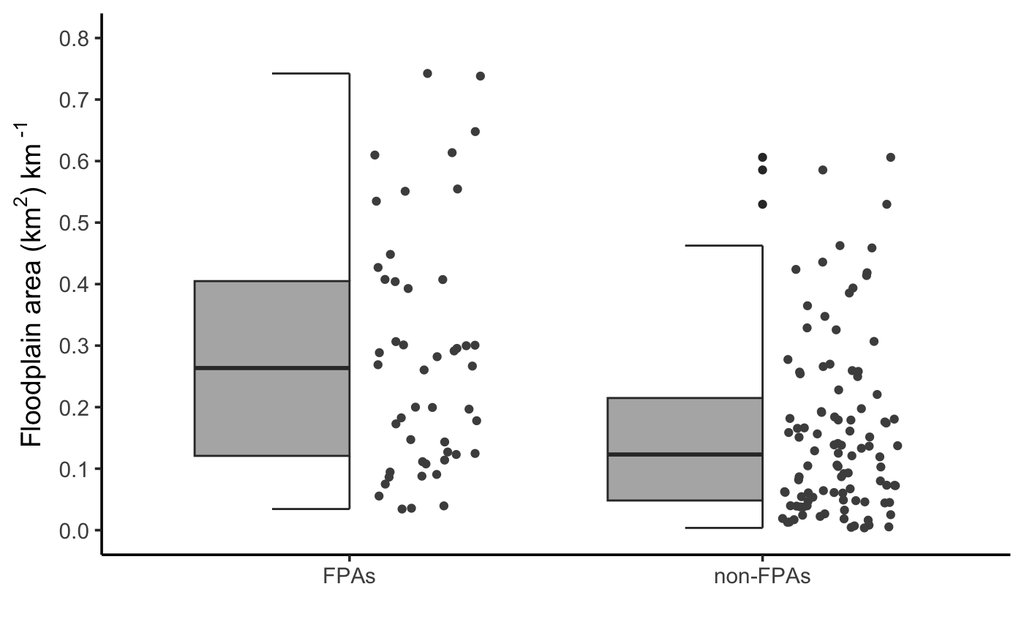

```r
init_floodplain_compare <-
  ggplot(floodplain_initial_df, aes(x = reserve_without_nj, y = initial_floodplain)) +
    geom_half_boxplot(fill="grey70")+
    geom_half_point(color="grey30")+
    scale_y_continuous(limits = c(0, 0.8), breaks=seq(0, 0.8, 0.1)) +
    scale_x_discrete(limits = c("Y", "N"),
                     breaks = c("Y", "N"),
                     labels = c("FPAs", "non-FPAs")) +
    labs (x = "", y = expression(paste("Floodplain area (km"^"2", ") km"^" -1"))) +
    theme_classic(base_size = 14) +
    theme(legend.position.inside = c(.99, .99),
          legend.justification = c("right", "top"),
          legend.box.just = "right")
init_floodplain_compare
```

**Compare the initial floodplain areas between the FPAs and non-FPAs using the Mann–Whitney U test**

```r
floodplain_initial_PAs <- floodplain_initial_df %>%
    filter(reserve_without_nj=="Y") %>% pull(initial_floodplain)
floodplain_initial_nonPAs <- floodplain_initial_df %>%
    filter(reserve_without_nj=="N") %>% pull(initial_floodplain)

floodplain_initial_outputs <- c(mean(floodplain_initial_PAs), sd(floodplain_initial_PAs),
                          mean(floodplain_initial_nonPAs), sd(floodplain_initial_nonPAs))
names(floodplain_initial_outputs) <- c("mean floodplain_initial_PAs", "sd floodplain_initial_PAs",
                                 "mean floodplain_initial_nonPAs", "sd floodplain_initial_nonPAs")
floodplain_initial_outputs
```

```
   mean floodplain_initial_PAs      sd floodplain_initial_PAs mean floodplain_initial_nonPAs   sd floodplain_initial_nonPAs
                     0.2785046                      0.1938652                      0.1571145                      0.1400132
```

```r
wilcox.test(initial_floodplain ~ reserve_without_nj, data=floodplain_initial_df)
```

```
    Wilcoxon rank sum test with continuity correction

data:  initial_floodplain by reserve_without_nj
W = 1440, p-value = 4.927e-05
alternative hypothesis: true location shift is not equal to 0
```

### 1.3 Compare the initial cropland% between the FPAs and non-FPAs

**Plot the initial cropland% between the FPAs and non-FPAs**

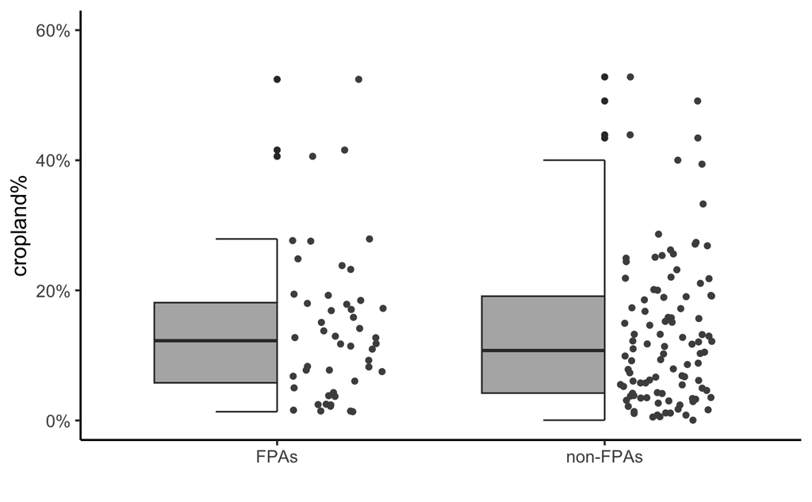

```r
init_crop_perc_compare <-
  ggplot(floodplain_initial_df, aes(x=reserve_without_nj, y=initial_crop_perc)) +
    geom_half_boxplot(fill="grey70")+
    geom_half_point(color="grey30")+
    scale_y_continuous(limits = c(0, 0.6), breaks=seq(0, 0.6, 0.2),
                       labels = scales::percent_format(accuracy = 1)) +
    scale_x_discrete(limits = c("Y", "N"),
                     breaks = c("Y", "N"),
                     labels = c("FPAs", "non-FPAs")) +
    labs (x = "", y = "cropland%") +
    theme_classic(base_size = 14) +
    theme(legend.position.inside = c(.99, .99),
          legend.justification = c("right", "top"),
          legend.box.just = "right")
init_crop_perc_compare
```

**Compare the initial cropland% between the FPAs and non-FPAs using the Mann–Whitney U test**

```r
crop_perc_initial_PAs <- floodplain_initial_df %>%
    filter(reserve_without_nj=="Y") %>% pull(initial_crop_perc)
crop_perc_initial_nonPAs <- floodplain_initial_df %>%
    filter(reserve_without_nj=="N") %>% pull(initial_crop_perc)

crop_perc_initial_outputs <- c(mean(crop_perc_initial_PAs), sd(crop_perc_initial_PAs),
                          mean(crop_perc_initial_nonPAs), sd(crop_perc_initial_nonPAs))
names(crop_perc_initial_outputs) <- c("mean crop_perc_initial_PAs", "sd crop_perc_initial_PAs",
                                 "mean crop_perc_initial_nonPAs", "sd crop_perc_initial_nonPAs")
crop_perc_initial_outputs
```

```
   mean crop_perc_initial_PAs      sd crop_perc_initial_PAs mean crop_perc_initial_nonPAs   sd crop_perc_initial_nonPAs
                    0.1397182                     0.1116309                     0.1328454                     0.1137565
```

```r
wilcox.test(initial_crop_perc ~ reserve_without_nj, data=floodplain_initial_df)
```

```
    Wilcoxon rank sum test with continuity correction

data:  initial_crop_perc by reserve_without_nj
W = 2308, p-value = 0.5741
alternative hypothesis: true location shift is not equal to 0
```

## 2. Compare initial urban% between FPAs and non-FPAs

```r
seg_urban_df <- read.csv(file="../../data/processed/seg_wise_urban.csv")
str(seg_urban_df)
```

```
'data.frame':   2550 obs. of  4 variables:
 $ f_year        : int  2001 2001 2001 2001 2001 2001 2001 2001 2001 2001 ...
 $ groups        : chr  "[0,10)" "[10,20)" "[20,30)" "[30,40)" ...
 $ year          : int  2001 2001 2001 2001 2001 2001 2001 2001 2001 2001 ...
 $ seg_urban_perc: num  0.2547 0.1314 0.0834 0.053 0.044 ...
```

### 2.1 Prepare the dataframe and add reserve information

```r
urban_initial_df <- seg_urban_df %>%
    mutate(f_year = as.factor(f_year),
           groups = factor(groups, levels=groups_levels)) %>% # get the group levels right
    filter(year <= 2006) %>%
    group_by(groups) %>%
    summarise(urban_perc_initial = mean(seg_urban_perc)) %>%
    mutate(f_group = c(1:150)) %>%
    mutate(reserve = case_when(f_group %in% c(22:30, 41:53, 88:104, 110:115, 127:131, 139:141) ~ "Y",
                               TRUE ~ "N")) %>%
    mutate(reserve_without_nj = case_when(f_group %in% c(22:30, 41:53, 88:104, 110:115, 139:141) ~ "Y",
                                          TRUE ~ "N")) %>%
    mutate(reserve_name = case_when(f_group %in% c(22:30) ~ "shishou",
                                    f_group %in% c(41:53) ~ "honghu",
                                    f_group %in% c(88:104) ~ "anqing",
                                    f_group %in% c(110:115) ~ "tongling",
                                    f_group %in% c(127:131) ~ "nanjing",
                                    f_group %in% c(139:141) ~ "zhenjiang",
                                    TRUE ~ "non-PAs")) %>%
    mutate(reserve = as.factor(reserve),
           reserve_without_nj = as.factor(reserve_without_nj),
           reserve_name = as.factor(reserve_name)) %>%
    # filter(f_group <= 145) %>%
    droplevels() %>%
    ungroup()
summary(urban_initial_df)
```

```
     groups    urban_perc_initial    f_group       reserve reserve_without_nj    reserve_name
 [0,10) :  1   Min.   :0.00000    Min.   :  1.00   N:97    N:102              anqing   :17
 [10,20):  1   1st Qu.:0.01192    1st Qu.: 38.25   Y:53    Y: 48              honghu   :13
 [20,30):  1   Median :0.05056    Median : 75.50                              nanjing  : 5
 [30,40):  1   Mean   :0.12301    Mean   : 75.50                              non-PAs  :97
 [40,50):  1   3rd Qu.:0.16790    3rd Qu.:112.75                              shishou  : 9
 [50,60):  1   Max.   :0.95440    Max.   :150.00                              tongling : 6
 (Other):144                                                                  zhenjiang: 3
```

**Plot the initial urban% between the FPAs and non-FPAs**

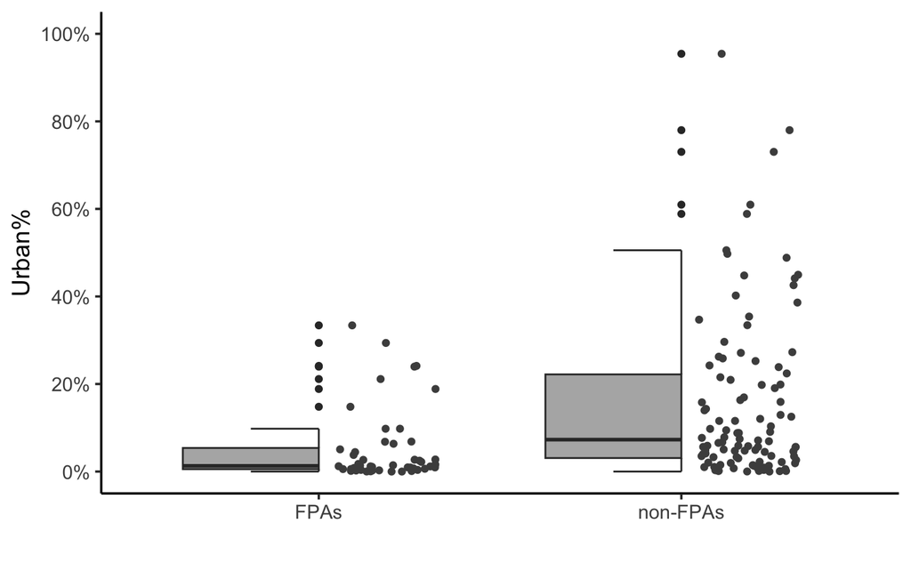

```r
init_urban_perc_compare <-
  ggplot(urban_initial_df, aes(x = reserve_without_nj, y = urban_perc_initial)) +
    geom_half_boxplot(fill="grey70") +
    geom_half_point(color="grey30") +
    scale_y_continuous(limits = c(0, 1), breaks=seq(0, 1, 0.2),
                       labels = scales::percent_format(accuracy = 1)) +
    scale_x_discrete(limits = c("Y", "N"),
                     breaks = c("Y", "N"),
                     labels = c("FPAs", "non-FPAs")) +
    labs (x = "", y = "Urban%") +
    theme_classic(base_size = 14) +
    theme(legend.position = c(.99, .99),
          legend.justification = c("right", "top"),
          legend.box.just = "right")
init_urban_perc_compare
```

**Compare the initial urban% between the FPAs and non-FPAs using the Mann–Whitney U test**

```r
urban_inital_PAs <- urban_initial_df %>% filter(reserve_without_nj =="Y") %>% pull(urban_perc_initial)
urban_inital_nonPAs <- urban_initial_df %>% filter(reserve_without_nj =="N") %>% pull(urban_perc_initial)

urban_inital_outputs <- c(mean(urban_inital_PAs), sd(urban_inital_PAs),
                          mean(urban_inital_nonPAs), sd(urban_inital_nonPAs))

names(urban_inital_outputs) <- c("mean urb_inital_PAs", "sd urb_inital_PAs",
                                 "mean urb_inital_nonPAs", "sd mean urb_inital_nonPAs")
urban_inital_outputs
```

```
      mean urb_inital_PAs         sd urb_inital_PAs    mean urb_inital_nonPAs sd mean urb_inital_nonPAs
               0.05220159                0.08362501                0.15633185                0.18970026
```

```r
wilcox.test(urban_perc_initial ~ reserve_without_nj, data=urban_initial_df)
```

```
    Wilcoxon rank sum test with continuity correction

data:  urban_perc_initial by reserve_without_nj
W = 3586, p-value = 4.587e-06
alternative hypothesis: true location shift is not equal to 0
```

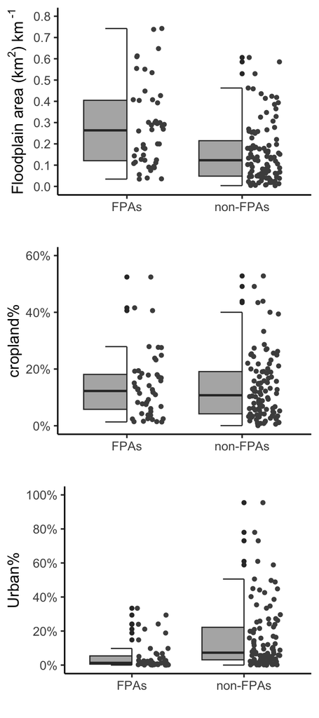

```r
combined_plot <- grid.arrange(init_floodplain_compare,
                              init_crop_perc_compare,
                              init_urban_perc_compare,
                              nrow = 3)
```

```r
combined_plot
```

| z | cells | name | grob |
| --- | --- | --- | --- |
| 1 | (1-1,1-1) | arrange | gtable[layout] |
| 2 | (2-2,1-1) | arrange | gtable[layout] |
| 3 | (3-3,1-1) | arrange | gtable[layout] |

```r
ggsave("../../results/figures/fig_5a_c_init_habitat.png", combined_plot, width = 4, height = 9)
```